# Lecture 3

Day 1

```python
import pandas as pd
import matplotlib.pyplot as plt
from matplotlib.pyplot import subplots
import seaborn as sns
import numpy as np
import scipy.integrate as spi
import scipy.stats as stats
import emcee
import astroML
from icecream import ic
```

Frequentist

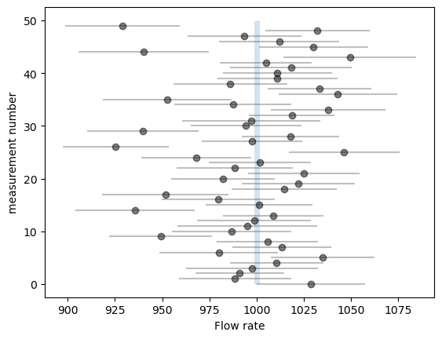

```python
np.random.seed(2) # for reproducibility
e = np.random.normal(30, 3, 50)
F = np.random.normal(1000, e) # mean = 1000, std = error of device

%matplotlib inline
import matplotlib.pyplot as plt

fig, ax = plt.subplots()
ax.errorbar(F, np.arange(50), xerr=e, fmt='ok', ecolor='gray', alpha=0.5)
ax.vlines([1000], 0, 50, linewidth=5, alpha=0.2)
ax.set_xlabel("Flow rate");ax.set_ylabel("measurement number");
plt.show()
```

```python
w = 1. / e ** 2
F_hat = np.sum(w * F) / np.sum(w)
sigma_F = w.sum() ** -0.5
print(F_hat,sigma_F)
```

```
998.6496963757094 4.113743971231106
```

Bayesian

```python
def log_prior(theta):
    return 1  # flat prior

def log_likelihood(theta, F, e):
    return -0.5 * np.sum(np.log(2 * np.pi * e ** 2)
                         + (F - theta[0]) ** 2 / e ** 2)

def log_posterior(theta, F, e):
    return log_prior(theta) + log_likelihood(theta, F, e)
```

```python
# np.random.seed(2) # for reproducibility
ndim = 1  # number of parameters in the model
nwalkers = 50  # number of MCMC walkers
nburn = 1000  # "burn-in" period to let chains stabilize
nsteps = 2000  # number of MCMC steps to take

# we'll start at random locations between 0 and 2000
starting_guesses = 2000 * np.random.rand(nwalkers, ndim)
sampler = emcee.EnsembleSampler(nwalkers, ndim, log_posterior, args=[F, e])
sampler.run_mcmc(starting_guesses, nsteps)

sample = sampler.chain  # shape = (nwalkers, nsteps, ndim)
sample = sampler.chain[:, nburn:, :].ravel()  # discard burn-in points
```

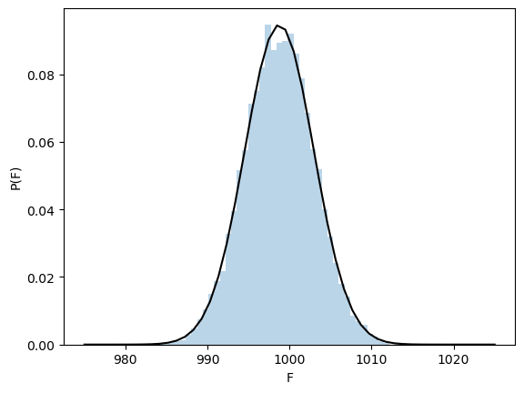

```python
# plot a histogram of the sample
from scipy import stats
plt.hist(sample, bins=50, histtype="stepfilled", alpha=0.3, density=True)

# plot a best-fit Gaussian
F_fit = np.linspace(975, 1025)
pdf = stats.norm(np.mean(sample), np.std(sample)).pdf(F_fit)

plt.plot(F_fit, pdf, '-k')
plt.xlabel("F"); plt.ylabel("P(F)")
plt.show()
```

```python
print(sample)
```

```
[ 998.76583626  998.60206312  998.05661687 ... 1002.96548681 1002.96548681
 1004.30426812]
```

```python
print("""
      F_true = {0}
      F_est  = {1:.0f} +/- {2:.0f} (based on {3} measurements)
      """.format(1000, np.mean(sample), np.std(sample), 50))
```

```
      F_true = 1000
      F_est  = 999 +/- 4 (based on 50 measurements)
```

Day 2

```python
np.random.seed(42)  # for reproducibility
N = 100  # we'll use more samples for the more complicated model
mu_true, sigma_true = 1000, 15  # stochastic flow rate model
F_true = stats.norm(mu_true, sigma_true).rvs(N)  # (unknown) true flow rate
F = stats.poisson(F_true).rvs()  # observed flow rate: true flow rate plus Poisson errors. # additive noise
e = np.sqrt(F)  # root-N error, as above
```

```python
def log_likelihood(theta, F, e):
    return -0.5 * np.sum(np.log(2 * np.pi * (theta[1] ** 2 + e ** 2))
                         + (F - theta[0]) ** 2 / (theta[1] ** 2 + e ** 2))

# maximize likelihood <--> minimize negative likelihood
def neg_log_likelihood(theta, F, e):
    return -log_likelihood(theta, F, e)

from scipy import optimize
theta_guess = [900, 5]
theta_est = optimize.fmin(neg_log_likelihood, theta_guess, args=(F, e))
print("""
      Maximum likelihood estimate for {0} data points:
          mu={theta[0]:.0f}, sigma={theta[1]:.0f}
      """.format(N, theta=theta_est))
```

```
Optimization terminated successfully.
         Current function value: 502.839505
         Iterations: 58
         Function evaluations: 114

      Maximum likelihood estimate for 100 data points:
          mu=999, sigma=19
```

```python
from astroML.resample import bootstrap

def fit_samples(sample):
    # sample is an array of size [n_bootstraps, n_samples]
    # compute the maximum likelihood for each bootstrap.
    return np.array([optimize.fmin(neg_log_likelihood, theta_guess,
                                   args=(F, np.sqrt(F)), disp=0)
                     for F in sample])

samples = bootstrap(F, 1000, fit_samples)  # 1000 bootstrap resamplings
mu_samp = samples[:, 0]
sig_samp = abs(samples[:, 1])

print (" mu    = {0:.0f} +/- {1:.0f}".format(mu_samp.mean(),
mu_samp.std()))
print (" sigma = {0:.0f} +/- {1:.0f}".format(sig_samp.mean(),
sig_samp.std()))
```

```
 mu    = 999 +/- 4
 sigma = 18 +/- 5
```

Bayesian

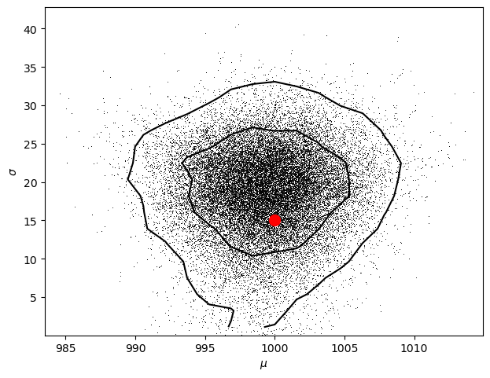

```python
def log_prior(theta):
    # sigma needs to be positive.
    if theta[1] <= 0:
        return -np.inf
    else:
        return 0

def log_posterior(theta, F, e):
    return log_prior(theta) + log_likelihood(theta, F, e)

# same setup as above:
ndim, nwalkers = 2, 50
nsteps, nburn = 2000, 1000

starting_guesses = np.random.rand(nwalkers, ndim)
starting_guesses[:, 0] *= 2000  # start mu between 0 and 2000
starting_guesses[:, 1] *= 20    # start sigma between 0 and 20

sampler = emcee.EnsembleSampler(nwalkers, ndim, log_posterior, args=[F,
e])
sampler.run_mcmc(starting_guesses, nsteps)

sample = sampler.chain  # shape = (nwalkers, nsteps, ndim)
sample = sampler.chain[:, nburn:, :].reshape(-1, 2)

from astroML.plotting import plot_mcmc
fig = plt.figure()
ax = plot_mcmc(sample.T, fig=fig, labels=[r'$\mu$', r'$\sigma$'],
colors='k')
ax[0].plot(sample[:, 0], sample[:, 1], ',k', alpha=0.8)

ax[0].plot([mu_true], [sigma_true], 'o', color='red', ms=10);
# plt.savefig('/content/drive/MyDrive/PSU/ColabNotebooks/Example3_3.png',
# dpi=300)
plt.show()
```

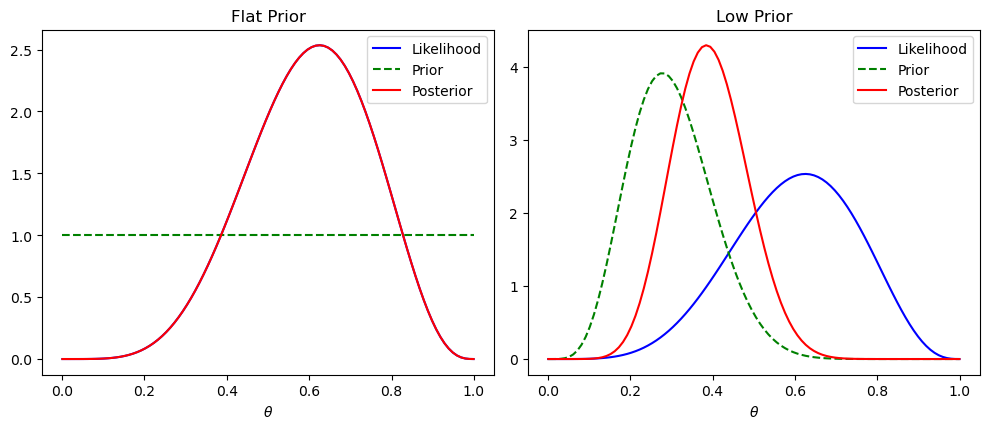

```python
import numpy as np
import matplotlib.pyplot as plt
from scipy.stats import beta

n, k = 8, 5

# Create a figure for the plots
fig = plt.figure(figsize=(10, 8))

# Plot 1: Flat prior
a, b = 1, 1
ax = fig.add_subplot(221)
theta = np.linspace(1e-3, 1 - 1e-3, 100)

# Likelihood, prior, and posterior plots
ax.plot(theta, beta.pdf(theta, k + 1, n - k + 1), label='Likelihood',
color='blue')
ax.plot(theta, beta.pdf(theta, a, b), ls='--', label='Prior',
color='green')
ax.plot(theta, beta.pdf(theta, k + a, n - k + b), label='Posterior',
color='red')

# Set axis label
ax.set_xlabel(r'$\theta$')

# Add a legend for the plots
ax.legend()

# Set the title for the subplot
ax.set_title('Flat Prior')

# Plot 2: Low prior
a, b = 6, 14
ax = fig.add_subplot(222)

# Likelihood, prior, and posterior plots
ax.plot(theta, beta.pdf(theta, k + 1, n - k + 1), label='Likelihood',
color='blue')
ax.plot(theta, beta.pdf(theta, a, b), ls='--', label='Prior',
color='green')
ax.plot(theta, beta.pdf(theta, k + a, n - k + b), label='Posterior',
color='red')

# Set axis label
ax.set_xlabel(r'$\theta$')


# Add a legend for the plots
ax.legend()

# Set the title for the subplot
ax.set_title('Low Prior')

# Show the figure
plt.tight_layout()
plt.show()
```

```python
# informative prior
c = a + b
theta_mean = (k+a)/(n+c)
theta_map = (k+a-1)/(n+c-2)

print(theta_mean)
print(theta_map)
# uninformative prior
theta_mle_mean = (k+1)/(n+2)
theta_mle_map = (k)/(n) # this is mle (just frequentist)

print(theta_mle_mean)
print(theta_mle_map)
```

```
0.39285714285714285
0.38461538461538464
0.6
0.625
```

```python
lmd = c/(n+c)
posterior_mean = (lmd*(a/c)) + ((1-lmd)*theta_mle_mean)
print(posterior_mean) # expected value of the posterior
var_mean = ((a+k)*(b+n-k))/(((a+k+b+n-k)**2)*(a+k+b+n-k+1))
print(var_mean) # variance of the posterior
```

```
0.3857142857142857
0.008224841660802252
```

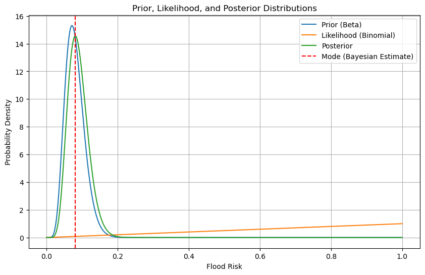

```
Bayesian estimate of flood risk (mode of posterior): 8.10%
```

```python
import numpy as np
import matplotlib.pyplot as plt
from scipy.stats import beta, binom

# Define the prior parameters (Beta distribution)
alpha_prior = 8
beta_prior = 92
# Define the likelihood parameters (Binomial distribution)
n_observed = 1  # One observed flood event exceeding the threshold
p_values = np.linspace(0, 1, 1001)  # A range of possible flood risk values

# Calculate the prior, likelihood, and posterior
prior = beta.pdf(p_values, alpha_prior, beta_prior)
likelihood = binom.pmf(n_observed, 1, p_values)  # Probability of observing 1 flood event given p
posterior = prior * likelihood

# Normalize the posterior to make it a valid probability distribution
posterior /= np.trapezoid(posterior, p_values)

# Calculate the mode of the posterior (Bayesian estimate)
mode_posterior = p_values[np.argmax(posterior)]

# Plot the prior, likelihood, and posterior distributions
plt.figure(figsize=(10, 6))
plt.plot(p_values, prior, label='Prior (Beta)')
plt.plot(p_values, likelihood, label='Likelihood (Binomial)')
plt.plot(p_values, posterior, label='Posterior')
plt.axvline(mode_posterior, color='red', linestyle='--', label='Mode (Bayesian Estimate)')
plt.xlabel('Flood Risk')
plt.ylabel('Probability Density')
plt.legend()
plt.title('Prior, Likelihood, and Posterior Distributions')
plt.grid()
plt.show()

print(f'Bayesian estimate of flood risk (mode of posterior): {mode_posterior:.2%}')
```

MCMC-MH Algorithim

```
Mean = 0.610, Std = 0.147
Target Mean is 0.5.
```

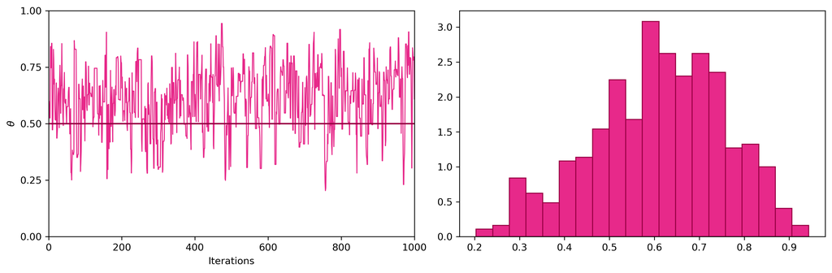

```python
x = np.linspace(0, 1000, 1000)
theta_vec = np.zeros(1000)

# we have a flat, uninformative priorbeta(1,1)
# binomial likelihood binom()

np.random.seed(42)

for i in range(1000):
    if i == 0:
        theta_vec[i] = 0.5
        # print(theta_vec[i], i)
    else:
        n, k = 8, 5 # 8 tosses, pick 5 heads

        theta_vec[i] = stats.norm.rvs(loc = theta_vec[i-1], scale = 0.2, size = 1)[0]
        r_MH = stats.beta.pdf(theta_vec[i], k+1, n - k + 1)/stats.beta.pdf(theta_vec[i-1], k+1, n-k+1) #Posterior(New)/Posterior(Old)
        acceptance_alpha = np.min([1, r_MH])
        u_MH = np.random.uniform(0, 1)
        if u_MH < acceptance_alpha:
            # print('Accept')
            theta_vec[i] = theta_vec[i]
        else:
            # print('Reject')
            theta_vec[i] = theta_vec[i-1]
        # print(theta_vec[i], i)


fig, ax = subplots(1,2,figsize=(12, 4), dpi=300, tight_layout=True)

ax[0].plot(x, theta_vec, color = '#e7298a', linewidth = 1)
ax[0].hlines(0.5, xmin = 0, xmax = 1000, color = '#980043')
ax[0].set_xlabel('Iterations')
ax[0].set_xlim(0, 1000)
ax[0].set_ylabel('$\\theta$')
ax[0].set_ylim(0, 1)
ax[0].set_yticks([0, 0.25, 0.5, 0.75, 1])[0]
ax[1].hist(theta_vec, color = '#e7298a', bins = 20, density = True, edgecolor = '#980043')

print(f"Mean = {np.mean(theta_vec):.3f}, Std = {np.std(theta_vec):.3f}")
print(f"Target Mean is 0.5.")
```

```
900.0 30.0 0
Mean = 2064.793, Std = 762.602
```

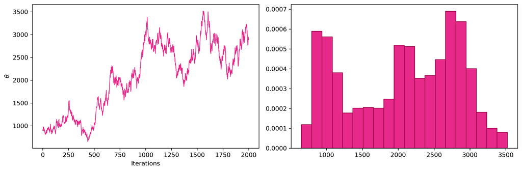

```python
x = np.linspace(0, 2000, 2000)

theta_vec = np.zeros(2000) # run a 2000 long markov chain
obs_theta = stats.norm.rvs(loc = 1000, scale = 100, size = 2000)

np.random.seed(42)

def r_MH_funct(theta_vec, obs_theta, i): # iteration
     return log_posterior(theta_vec, obs_theta[i], obs_theta[i])/log_posterior(theta_vec, obs_theta[i-1], obs_theta[i-1])

## make obs. values

for i in range(len(theta_vec)):
    if i == 0:
        theta_vec[i] = 900
        print(theta_vec[i], np.sqrt(theta_vec[i]), i)
    else:
        sigma = np.sqrt(theta_vec[i-1])
        theta_vec[i] = stats.norm.rvs(loc = theta_vec[i-1], scale = sigma, size = 1)[0]

        # print(theta_vec[i-1], np.sqrt(theta_vec[i-1]), i-1)

        r_MH = r_MH_funct(theta_vec, obs_theta, i)

        # r_MH = log_posterior(theta_vec, obs_theta[i], np.sqrt(theta_vec[i]))/log_posterior(theta_vec, obs_theta[i-1], np.sqrt(theta_vec[i-1])) #Posterior(New)/Posterior(Old)

        acceptance_alpha = np.min([1, r_MH])
        u_MH = np.random.uniform(0, 1)
        if u_MH < acceptance_alpha:
            # print('Accept')
            theta_vec[i] = theta_vec[i]
        else:
            # print('Reject')
            theta_vec[i] = theta_vec[i-1]
        # print(theta_vec[i], i)


fig, ax = subplots(1,2,figsize=(12, 4), dpi=300, tight_layout=True)

ax[0].plot(x, theta_vec, color = '#e7298a', linewidth = 1)
# ax[0].hlines(0.5, xmin = 0, xmax = 1000, color = '#980043')
ax[0].set_xlabel('Iterations')
# ax[0].set_xlim(0, 1000)
ax[0].set_ylabel('$\\theta$')
# ax[0].set_ylim(0, 1)
# ax[0].set_yticks([0, 0.25, 0.5, 0.75, 1])[0]
ax[1].hist(theta_vec, color = '#e7298a', bins = 20, density = True, edgecolor = '#980043')

print(f"Mean = {np.mean(theta_vec):.3f}, Std = {np.std(theta_vec):.3f}")
# print(f"Target Mean is 0.5.")
```

[spacer]

Josh's Code

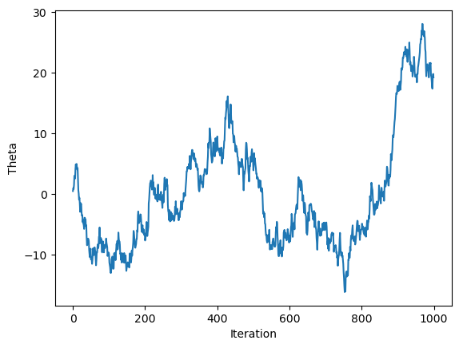

```python
# Set random seed
np.random.seed(42)

# MCMC

#Set initial conditions
sigma = 1 # Assume sigma doesn't change

# Length of chain
N=1000

# Initial theta
theta_init = 0.5 #stats.norm.rvs(loc=0.5, scale=sigma, size=1)

theta_array = np.zeros(N)
theta_array[0] = theta_init

for t in np.arange(1,1000):
  theta_array[t] = stats.norm.rvs(loc=theta_array[t-1], scale=sigma)

plt.plot(theta_array)
plt.xlabel("Iteration")
plt.ylabel("Theta")
```

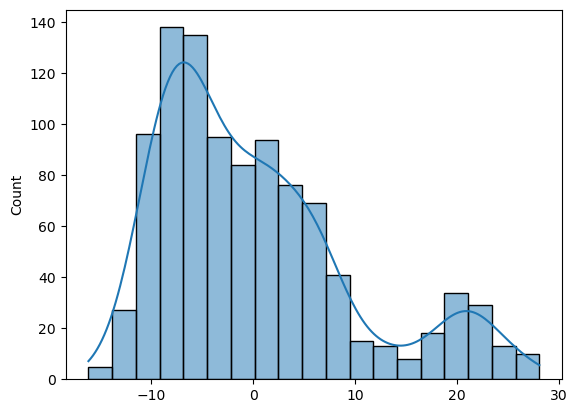

```python
sns.histplot(theta_array, stat='count', kde=True)
```

```python
#MCMC-MH
def metropolis_hastings(theta_new, theta):
  r = posterior_cointoss(theta_new) / posterior_cointoss(theta)
  theta_out = theta
  if r > 1:
    theta_out=theta_new
  elif r <=1:
    alpha=np.min([r,1])
    u = stats.uniform().rvs(1)
    if u<alpha:
      theta_out=theta_new
    else:
      theta_out=theta
  return theta_out

def posterior_cointoss(theta):
  n, k = 8, 5
  a, b = 1,1 # flat prior
  posterior = stats.beta.pdf(theta, k + a, n - k + b)
  return posterior
```

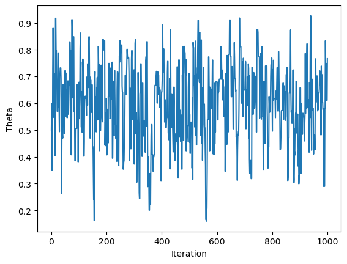

```python
# Set random seed
np.random.seed(42)

# Length of chain
N=1000

# Initial theta
theta_init = 0.5 #stats.norm.rvs(loc=0.5, scale=sigma, size=1)
sigma = 0.2 # Assume sigma doesn't change

theta_array = np.zeros(N)
theta_array[0] = theta_init

for t in np.arange(1,1000):
  # Corrected np.min and np.max to accept lists for comparison
  theta_new = np.clip(stats.norm.rvs(loc=theta_array[t-1], scale=sigma), 0, 1)
  theta_array[t] = metropolis_hastings(theta_new,theta_array[t-1])

plt.plot(theta_array)
plt.xlabel("Iteration")
plt.ylabel("Theta")
```

```
mean:  0.601268086916836
std:  0.14634169208378917
```

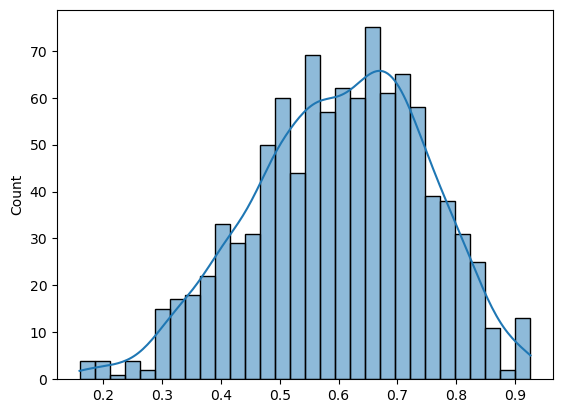

```python
sns.histplot(theta_array, stat='count', kde=True, bins=30)
print('mean: ', theta_array.mean())
print('std: ', theta_array.std())
#
```

# CE410/510: Modern Statistics for Engineers, Homework 3

Completed by Brandon Auyeung for Dr. Peyman Abbaszadeh

Due Date: 2nd of February, 2026

```python
import matplotlib.pyplot as plt
from matplotlib.pyplot import subplots
import seaborn as sns
import numpy as np
import scipy.stats as stats
```

## Problem 1.

### Part a

$$ \mathcal{L} = \mathbb{P}(x | \lambda) = \frac{1}{Z(\lambda)} \left[\frac{1}{\lambda}\right] e^{-\frac{x}{\lambda}} \ \text{if} \ x \in [1,20] $$

where:

$$ Z(\lambda) = \int_1^{20} \frac{1}{\lambda}e^{-\frac{x}{\lambda}} dx = e^{-\frac{1}{\lambda}} - e^{-\frac{20}{\lambda}}$$

Visualize $ \mathbb{P}(x|\lambda) \ \text{for} \ \lambda = 2, 5, 10 $

```python
lmbds = np.array([2,5,10]) # define lambda values for visualization

def Z_func(lamb): # define Z function
    return np.exp(-1/lamb) - np.exp(-20/lamb)

def likelihood(x, lamb, x_axis, lamb_axis): # define likelihood

    if len(x_axis) > len(lamb_axis): # use the longer array
        L = np.zeros(len(x_axis))
        for index, value in enumerate(x):
            if value < 1 or value > 20: # guard clause: x must be between 1 and 20
                print('x must be between 1 and 20')
                return
            else:
                L[index] = (1/(Z_func(lamb))) * (1/lamb) * np.exp(-value/lamb)
    else:
        L = np.zeros(len(lamb_axis))
        for index, value in enumerate(lamb):
                L[index] = (1/(Z_func(value))) * (1/value) * np.exp(-x/value)
    return L
```

```
(0.0, 0.5)
```

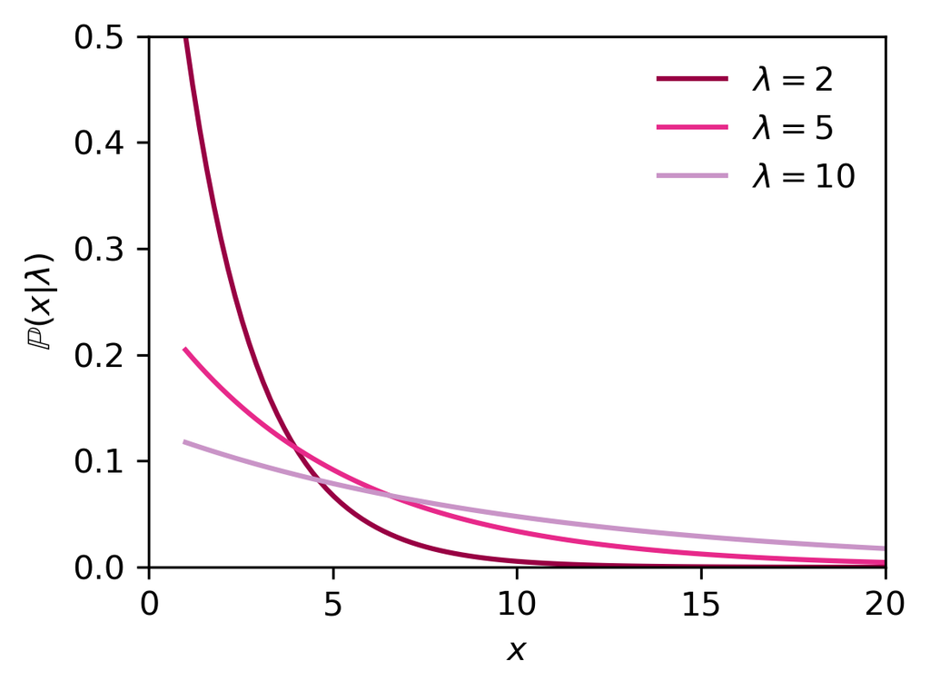

```python
x_axis = np.linspace(1, 20, 100) # define x values for visualization
colors = ['#980043', '#e7298a', '#c994c7']

fig, ax = subplots(figsize=(4, 3), dpi=300, tight_layout=True)

for index, lamb in enumerate(lmbds):
    ax.plot(x_axis, likelihood(x_axis, lamb, x_axis, lmbds), label=f'$\\lambda = {lamb}$', color=colors[index]) # plot likelihood for each lambda value
plt.xlabel('$x$')
plt.ylabel('$\\mathbb{P}(x|\\lambda)$')
plt.legend(frameon = False, loc = 'best')
plt.xlim(0, 20)
plt.ylim(0, 0.5)
```

### Part b

Visualize $ \mathbb{P}(x|\lambda) \ \text{for} \ x = 2, 5, 10 $

```
(0.0, 0.5)
```

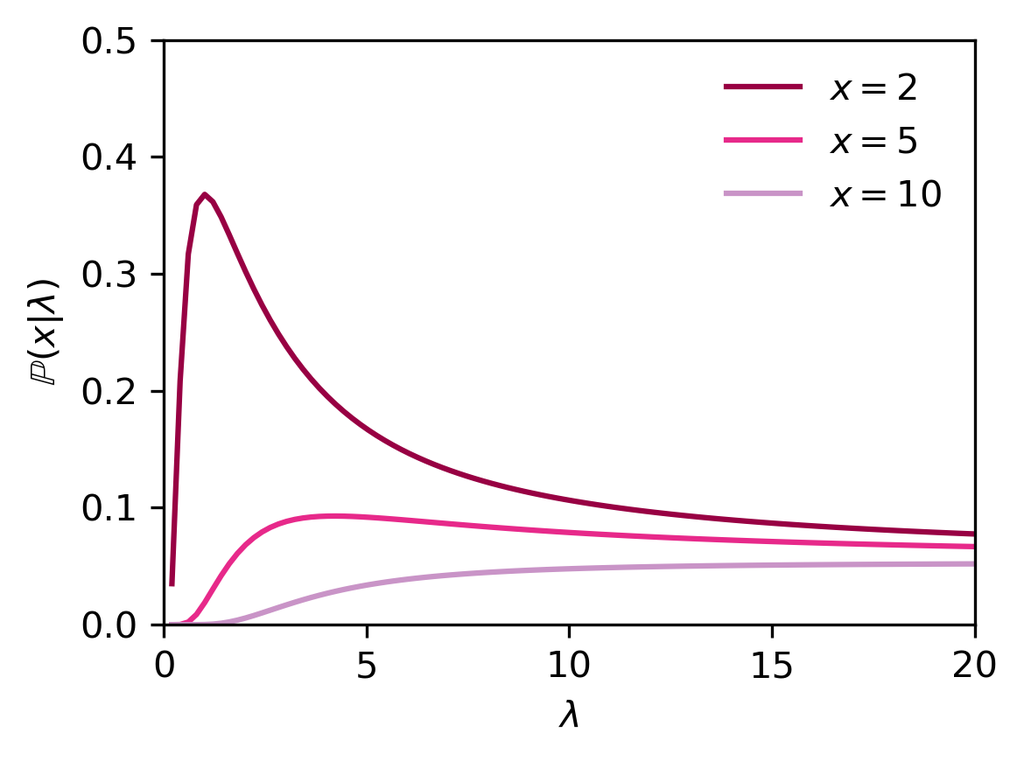

```python
lamb_axis = np.linspace(0, 20, 100) # define lambda values for visualization
x = np.array([2,5,10])
fig, ax = subplots(figsize=(4, 3), dpi=300, tight_layout=True)

for index, value in enumerate(x):
    ax.plot(lamb_axis, likelihood(value, lamb_axis, x, lamb_axis), label=f'$x = {value}$', color=colors[index]) # plot likelihood for each lambda value
plt.xlabel('$\\lambda$')
plt.ylabel('$\\mathbb{P}(x|\\lambda)$')
plt.legend(frameon = False, loc = 'best')
plt.xlim(0, 20)
plt.ylim(0, 0.5)
```

Assume $ D = \{3,7,2,12,5\}$ and assume the posterior is shaped as follows.

$$ \mathbb{P}(\lambda | D) = \frac{\mathbb{P}(D|\lambda)\mathbb{P}(\lambda)}{\mathbb{P}(D)} \propto \frac{1}{[\lambda(Z(\lambda))]^N} \ \text{exp}\left( -\sum_i^n \frac{D_i}{\lambda} \right) \mathbb{P}(\lambda) $$

$$ Z(\lambda) = \int_1^{20} \frac{1}{\lambda}e^{-\frac{D}{\lambda}} dD = e^{-\frac{1}{\lambda}} - e^{-\frac{20}{\lambda}}$$

1. an uninformative (i.e. flat) prior
2. a Gaussian prior of form $\mathbb{P}(\lambda) = \mathcal{N}(10,5^2)$

```python
x_range = np.linspace(0,1,100) # define x values for visualization
D = np.array([3,7,2,12,5])
flat_prior = stats.beta.pdf(x_range, 1, 1) # flat prior from range 0 to 20
gaussian_prior = stats.norm.pdf(x_range, 10, 5) # gaussian prior from range 0 to 20

def posterior_3(x, lamb, x_axis, lamb_axis): # define likelihood

    if len(x_axis) > len(lamb_axis): # use the longer array
        post = np.zeros(len(x_axis))
        for index, value in enumerate(x):
                post[index] = (1/(lamb*Z_func(lamb))**len(x_axis)) * (np.exp(-np.sum(x[index]/lamb)))*x_axis[index]
    else:
        post = np.zeros(len(lamb_axis))
        for index, value in enumerate(lamb):
                post[index] = (1/(lamb*Z_func(lamb))**len(x_axis)) * (np.exp(-np.sum(x[index]/lamb)))*x_axis[index]
    return post

post_flat = np.zeros(len(x_range))
post_gaussian = np.zeros(len(x_range))

for index, value in enumerate(D):
    post_flat[index] = posterior_3(x_range, value, flat_prior, D)
    post_gaussian[index] = posterior_3(x_range, value, gaussian_prior, D)


fig, ax = subplots(1,2,figsize=(12, 4), dpi=300, tight_layout=True)

ax[0].plot(x_range, post_flat, color = '#e7298a', linewidth = 1)
ax[0].set_xlabel('$x$')
# ax[0].set_xlim(0, 20)
ax[0].set_ylabel('$\\mathbb{P}(x|\\lambda)$')
# ax[0].set_ylim(0, 0.5)
# ax[0].set_yticks([0, 0.25, 0.5])[0]
ax[1].plot(x_range, gaussian_prior, color = '#e7298a', linewidth = 1)
```

[output not shown]

# CE410/510: Modern Statistics for Engineers, Homework 3

Completed by Brandon Auyeung for Dr. Peyman Abbaszadeh

Due Date: 25th of February, 2026

## Problem 3

Coin toss problem: Drive the posterior distribution of parameter $\theta$, which is the probability that a coin toss results in heads. Suppose that the prior distribution is an uninformative (or flat) Beta distribution with parameters of $ a, b = 1, 1 $. We use Binomial likelihood function to quantify the data from our experiment which resulted in 4 heads out of 10 tosses.

### Part 3a

Use Monte Carlo (MC) approach. Visualize the MC evolution and the density plot for θ based on 1000 iterations. Use np.random.seed(5) and the proposal distribution that follows a Gaussian distribution with a mean and standard deviation of 0.5 and 0.05, respectively. Please discuss what the results would be if we increased the iterations to 10000. (2 points)

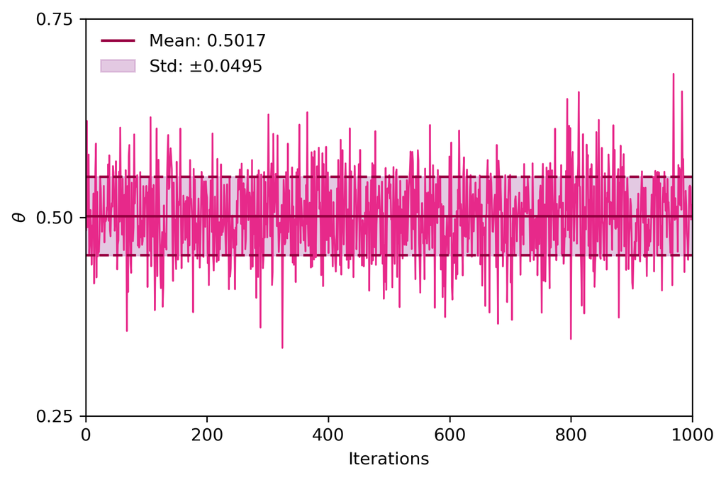

```python
x = np.linspace(0, 1000, 1000) # define how many iterations will be run
theta_mc = np.zeros(1000) # define empty theta array for monte carlo simulation

np.random.seed(5) # set random seed

for i in range(1000): # for each iteration...
    theta_mc[i] = stats.norm.rvs(loc = 0.5, scale = 0.05, size = 1)[0]
    # draw a sample from a normal distribution with mean 0.5 and standard deviation 0.05

fig, ax = subplots(figsize=(6, 4), dpi=300, tight_layout=True)

ax.plot(x, theta_mc, color = '#e7298a', linewidth = 1) # plot theta values over iterations

# visualize mean and standard deviation of theta samples
ax.hlines(np.mean(theta_mc), xmin = 0, xmax = 1000, color = '#980043', label = f'Mean: {np.mean(theta_mc):.4f} ')
ax.hlines(np.mean(theta_mc) + np.std(theta_mc), xmin = 0, xmax = 1000, linestyles= "--",color = '#980043')
ax.hlines(np.mean(theta_mc) - np.std(theta_mc), xmin = 0, xmax = 1000, linestyles= "--",color = '#980043')
ax.fill_between(x, np.mean(theta_mc) - np.std(theta_mc), np.mean(theta_mc) + np.std(theta_mc), color = '#c994c7', alpha = 0.5, label = f'Std: $\\pm${np.std(theta_mc):.4f} ')

# format plot
ax.set_xlabel('Iterations')
ax.set_xlim(0, 1000)
ax.set_ylabel('$\\theta$')
ax.set_ylim(0.25, 0.75)
ax.set_yticks([0.25, 0.5, 0.75])[0]
plt.legend(frameon = False, loc = 'best')
```

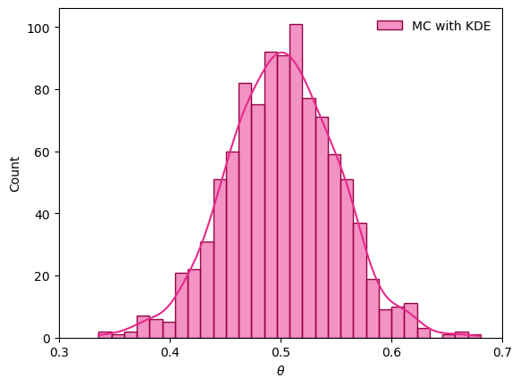

```python
# create and format histogram with kernel density estimate
sns.histplot(theta_mc, kde=True, bins=30, color = '#e7298a', edgecolor = '#980043', label = 'MC with KDE')
plt.xlabel('$\\theta$')
plt.ylabel('Count')
plt.xticks([0.3, 0.4, 0.5, 0.6, 0.7])
plt.legend(frameon = False, loc = 'best')
plt.show()
```

**Discussion for Part 3a**

As the number of iterations becomes large (i.e. as $N \rightarrow \infty$), the resultant posterior distribution approaches the proposal distribution. No evolution can occur since all values draw directly from the proposal distribution. Therefore, if $N = 10000$, the shape of the KDE would approach the proposal distribution's shape.

### Part 3b

Use Markov Chain Monte Carlo (MCMC) approach. Visualize the MCMC evolution and the density plot for $\theta$ based on 1000 iterations. Use np.random.seed(5) and the proposal distribution that follows a Gaussian distribution with a mean and standard deviation of 0.5 and 0.05, respectively. Please discuss what the results would be if we increased the iterations to 10000. (2 points)

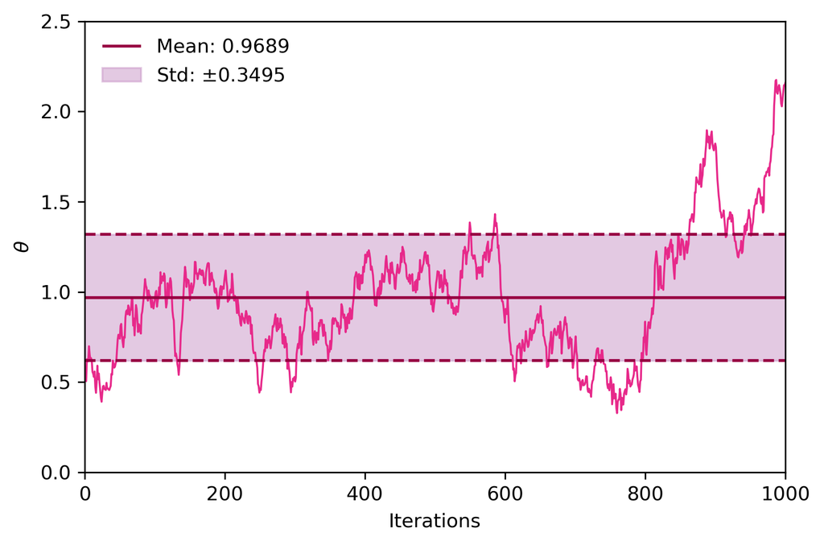

```python
theta_mcmc = np.zeros(1000) # define empty theta array for mcmc simulation
np.random.seed(5) # set random seed

for i in range(1000): # for each iteration...
    if i == 0:
        theta_mcmc[i] = 0.5 # set theta to 0.5 for iteration 0
    else:
        theta_mcmc[i] = stats.norm.rvs(loc = theta_mcmc[i-1], scale = 0.05, size = 1)[0]
        # for all other iterations, draw a sample from a normal distribution with mean theta from the previous iteration and standard deviation 0.2

fig, ax = subplots(figsize=(6,4), dpi=300, tight_layout=True)

ax.plot(x, theta_mcmc, color = '#e7298a', linewidth = 1) # plot theta values over iterations

# visualize mean and standard deviation of theta samples
ax.hlines(np.mean(theta_mcmc), xmin = 0, xmax = 1000, color = '#980043', label = f'Mean: {np.mean(theta_mcmc):.4f} ')
ax.hlines(np.mean(theta_mcmc) + np.std(theta_mcmc), xmin = 0, xmax = 1000, linestyles= "--",color = '#980043')
ax.hlines(np.mean(theta_mcmc) - np.std(theta_mcmc), xmin = 0, xmax = 1000, linestyles= "--",color = '#980043')
ax.fill_between(x, np.mean(theta_mcmc) - np.std(theta_mcmc), np.mean(theta_mcmc) + np.std(theta_mcmc), color = '#c994c7', alpha = 0.5, label = f'Std: $\\pm${np.std(theta_mcmc):.4f} ')

# format plot
ax.set_xlabel('Iterations')
ax.set_xlim(0, 1000)
ax.set_ylabel('$\\theta$')
ax.set_ylim(0, 2.5)
plt.legend(frameon = False, loc = 'best')
```

[figure not shown]

```python
# create and format histogram with kernel density estimate
sns.histplot(theta_mcmc, kde=True, bins=30, color = '#e7298a', edgecolor = '#980043', label = 'MCMC with KDE')
plt.xlabel('$\\theta$')
plt.ylabel('Count')
plt.xlim(0, 7.5)
plt.legend(frameon = False, loc = 'best')
plt.show()
```

**Discussion for Part 3b**

As the number of iterations becomes large (i.e. as $N \rightarrow \infty$), the resultant posterior distribution is allowed to evolve without bound. Therefore, if $N = 10000$, the shape of the KDE may spiral into a non-sensical result.

### Part 3c

Use Markov Chain Monte Carlo (MCMC) with Metropolis-Hasting (MH) approach. Visualize the MCMC evolution and the density plot for $\theta$ based on 1000 iterations. Use np.random.seed(5) and the proposal distribution that follows a Gaussian distribution with a mean and standard deviation of 0.5 and 0.05, respectively. Please discuss what the results would be if we increased the iterations to 10000 with a burn-in period of 200. (6 points)

i) Compare the density plot of 𝜃 provided by MCMC-MH with the theoretical posterior distribution, and discuss the results.

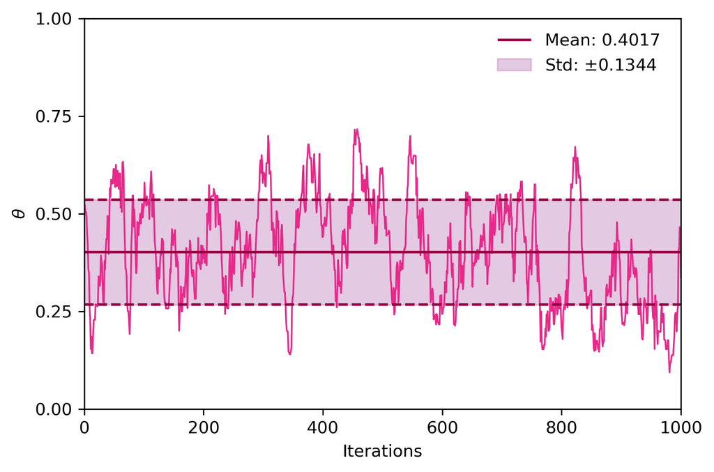

```python
theta_vec = np.zeros(1000) # define empty theta array for mcmc-mh simulation
np.random.seed(5) # set random seed

for i in range(1000): # for each iteration...
    if i == 0:
        theta_vec[i] = 0.5 # set theta to 0.5 for iteration 0
    else:
        n, k = 10, 4 # 10 tosses, pick 4 heads
        theta_vec[i] = stats.norm.rvs(loc = theta_vec[i-1], scale = 0.05, size = 1)[0]
        # for all other iterations, draw a sample from a normal distribution with mean theta from the previous iteration and standard deviation 0.2
        r_MH = stats.beta.pdf(theta_vec[i], k+1, n - k + 1)/stats.beta.pdf(theta_vec[i-1], k+1, n-k+1)
        #Posterior(New)/Posterior(Old) computes the metropolis-hastings ratio
        acceptance_alpha = np.min([1, r_MH])
        # acceptance probability is the minimum of 1 and the MH ratio
        u_MH = np.random.uniform(0, 1) # draw a random number between 0 and 1
        if u_MH < acceptance_alpha:
            # print('Accept')
            theta_vec[i] = theta_vec[i] # accept the new mean
        else:
            # print('Reject')
            theta_vec[i] = theta_vec[i-1] # reject the new mean and use the old mean

fig, ax = subplots(figsize=(6,4), dpi=300, tight_layout=True)

ax.plot(x, theta_vec, color = '#e7298a', linewidth = 1) # plot theta values over iterations

# visualize mean and standard deviation of theta samples
ax.hlines(np.mean(theta_vec), xmin = 0, xmax = 1000, color = '#980043', label = f'Mean: {np.mean(theta_vec):.4f} ')
ax.hlines(np.mean(theta_vec) + np.std(theta_vec), xmin = 0, xmax = 1000, linestyles= "--",color = '#980043')
ax.hlines(np.mean(theta_vec) - np.std(theta_vec), xmin = 0, xmax = 1000, linestyles= "--",color = '#980043')
ax.fill_between(x, np.mean(theta_vec) - np.std(theta_vec), np.mean(theta_vec) + np.std(theta_vec), color = '#c994c7', alpha = 0.5, label = f'Std: $\\pm${np.std(theta_vec):.4f} ')

# format plot
ax.set_xlabel('Iterations')
ax.set_xlim(0, 1000)
ax.set_ylabel('$\\theta$')
ax.set_ylim(0, 1)
ax.set_yticks([0, 0.25, 0.5, 0.75, 1])[0]
plt.legend(frameon = False, loc = 'best')
```

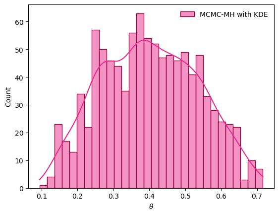

```python
# create and format histogram with kernel density estimate
sns.histplot(theta_vec, kde=True, bins=30, color = '#e7298a', edgecolor = '#980043', label = 'MCMC-MH with KDE')
plt.xlabel('$\\theta$')
plt.ylabel('Count')
plt.legend(frameon = False, loc = 'best')
plt.show()
```

This coin flip problem uses a flat prior of $\mathcal{Prior} \sim \beta(a = 1, b = 1)$ and a binomial likleyhood of $\mathcal{L} \sim \text{Binom}(\theta, n = 10, k =4)$. This selection of prior is a *conjugate prior* which allows the posterior to follow the same distribution as the prior with updated parameters.

The theoretical posterior may be computed as follows.

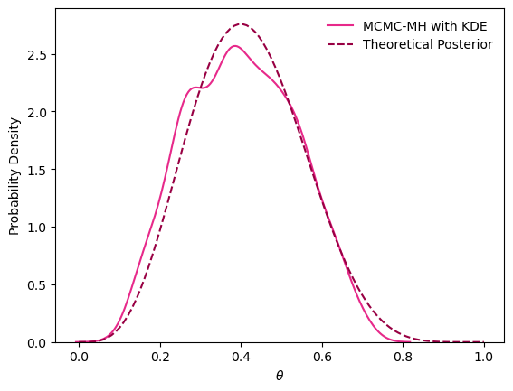

```python
# plot kernel density estimate for MCMC-MH by itself
sns.kdeplot(theta_vec, color = '#e7298a', label = 'MCMC-MH with KDE')

# compute theoretical posterior
post_theo = stats.beta.pdf(np.linspace(0, 1, 100), 4+1, 10 - 4 + 1)

# plot theoretical posterior and format
plt.plot(np.linspace(0, 1, 100), post_theo, color = '#980043', linestyle = '--', label = 'Theoretical Posterior')
plt.legend(frameon = False, loc = 'best')
plt.xlabel('$\\theta$')
plt.ylabel('Probability Density')
```

**Discussion for Part 3c**

As the number of iterations becomes large (i.e. as $N \rightarrow \infty$), the resultant posterior distribution is allowed to evolve in a more resonable fashion. The $r_{MH}$ (i.e. Metropolis Hastings Ratio) prevents the issue of non-sensical evolution without preventing evolution altogether. Therefore, if $N = 10000$, the shape of the KDE is able to reflect an accuratly updated posterior distrubiton that has combined prior knowledge with experimental results (i.e. likleyhood values).

As can be seen in the above figure, the KDE density plot is able to resemble the theoretical posterior well. With more experiments, the posterior is eventually likely able to converge to the theoretical posterior.